# Imports

```python
from numpy import array, arange, zeros, transpose, cos, sin, arange
from matplotlib import pyplot, rc
from math import pi
```

# The System Models

The following differential equations represent the velocity dynamics of the two DC motors attached to Romi's wheels. The chassis dynamics are left to the student to implement. The inputs $u_L$ and $u_R$ are the left and right motor voltages which, through the motor dynamics, cause the velocities $\Omega_L$ and $\Omega_R$ to be produced.

$$ \begin{array}{rl} \frac{d\Omega_L}{dt} &= \frac{K}{\tau} u_L - \frac{1}{\tau} \Omega_L \\[6pt] \frac{d\Omega_R}{dt} &= \frac{K}{\tau} u_R - \frac{1}{\tau} \Omega_R \end{array} $$

The preceding equations can be combined into a single vector equation so that we can solve it using vector based ODE solution techniques.

$$ \begin{array}{rl} \frac{d}{dt} \begin{bmatrix} \Omega_L \\[6pt] \Omega_R \\[6pt] \end{bmatrix} &= \begin{bmatrix} \frac{K}{\tau} u_L - \frac{1}{\tau} \Omega_L \\[6pt] \frac{K}{\tau} u_R - \frac{1}{\tau} \Omega_R \\[6pt] \end{bmatrix} \end{array} $$

The preceding sytem of equations are of the form $\dot{\mathbf{x}} = \mathbf{f}\left(t, \mathbf{x}\right)$ which is the standard form for nonlinear state-space systems. This system of equations represent the dynamics of the entire system; that is, all of the differential equations are wrapped up in one large matrix equation.

It is often the case that outputs of interest are not present in the state vector directly. In such instances a second set of equations is utilized to select outputs of interest in the form $\mathbf{y} = \mathbf{g}\left(t, \mathbf{x}\right)$. For the DC motor model, the desired outputs will include all state variables and also the coordinate of an arbitrary "point of interest" attached to Romi's chassis. $$ \begin{array}{rl} \begin{bmatrix} \Omega_L \\[6pt] \Omega_R \\[6pt] \end{bmatrix} &= \begin{bmatrix} \Omega_L \\[6pt] \Omega_R \\[6pt] \end{bmatrix} \end{array} $$

In the code below, there are two different functions defined; each one implements both the state equations, $\dot{\mathbf{x}} = \mathbf{f}\left(t, \mathbf{x}\right)$, and the output equations, $\mathbf{y} = \mathbf{g}\left(t, \mathbf{x}\right)$. The difference between the two functions is that the first implements an open-loop simulation and the second implements a closed loop simulation.

```python
# Electromechanical properties
K      = 250*2*pi/60/4.5     # Motor Gain [rad/(V*s)]
tau    = 0.1                 # Motor Time Constant [s]

# Physical Properties (cm)
w = 14.9
r = 3.5
```

## Open Loop System Model

```python
def system_eqn_OL(t, x):
    '''!@brief      Implements both state equations and output equations for the
                    open loop system
        @param t    The value of time for a given simulation step
        @param x    The value of the state vector for a given simulation step
        @return     A tuple containing both the derivative of the state vector
                    and the output vector for a given simulation step
    '''

    # Open-loop inputs for radius ~50cm
    # derived from forward and angular velocity equations
    # radius = v/w
    u = array([ [ 4.05 ],
                [ 3.0 ] ])


    # State equations
    # State vector: x = [psi, S, omegaL, omegaR, X, Y]

    psi = x[0,0]
    S = x[1,0]
    omegaL = x[2,0]
    omegaR = x[3,0]
    X = x[4,0]
    Y = x[5,0]

    # State derivatives:
    # Psi_dot = (r/w)(omegaR-omegaL)
    # S_dot = (r/2)(omegaR+omegaL)
    # OmegaL_dot = (K/tau)(uL) - omegaL/tau
    # OmegaR_dot = (K/tau)(uR) - omegaR/tau
    # X_dot = (r/2)(omegaR+omegaL)cos(psi)
    # Y_dot = (r/2)(omegaR+omegaL)sin(psi)

    xd =  array( [ [ (r/w)*(omegaR - omegaL)          ],
                   [ (r/2)*(omegaR + omegaL)          ],
                   [ K/tau*u[0,0] - 1/tau*omegaL      ],
                   [ K/tau*u[1,0] - 1/tau*omegaR      ],
                   [ (r/2)*(omegaR + omegaL)*cos(psi) ],
                   [ (r/2)*(omegaR + omegaL)*sin(psi) ] ] )

    # Output Equations
    # Output vector: y = [omegaL, omegaR, sL, sR, psi, psi_dot, X, Y]

    y  =  array( [ [ omegaL         ],  # Left motor velocity [rad/s]
                   [ omegaR         ],  # Right motor velocity [rad/s]
                   [ S - (w/2)*psi  ],  # Left wheel arc length [cm]
                   [ S + (w/2)*psi  ],  # Right wheel arc length [cm]
                   [ psi            ],  # Heading angle [rad]
                   [ xd[0,0]        ],  # Angular velocity (psi_dot) [rad/s]
                   [ X              ],  # X position [cm]
                   [ Y              ] ])# Y position [cm]

    return xd, y
```

## Closed Loop System Model

```python
def system_eqn_CL(t, x):
    '''!@brief      Implements both state equations and output equations for
                    the closed-loop system
        @param t    The value of time for a given simulation step
        @param x    The value of the state vector for a given simulation step
        @return     A tuple containing both the derivative of the state vector
                    and the output vector for a given simulation step
    '''

    # Desired trajectory
    v_desired = 20.0      # Desired forward velocity (cm/s)
    R_desired = 50.0      # Desired circle radius (cm)

    # Control gain
    Kp = 2.0

    # Compute desired angular velocity for circular motion
    omega_desired = v_desired / R_desired  # (rad/s)

    # Compute desired wheel velocities
    omegaL_desired = v_desired/r - (w/(2*r))*omega_desired
    omegaR_desired = v_desired/r + (w/(2*r))*omega_desired

    # Get state variables
    psi = x[0,0]
    S = x[1,0]
    omegaL = x[2,0]
    omegaR = x[3,0]
    X = x[4,0]
    Y = x[5,0]

    # Proportional control
    u_L = Kp * (omegaL_desired - omegaL)
    u_R = Kp * (omegaR_desired - omegaR)

    u = array([ [ u_L ],
                [ u_R ] ])

    # State derivatives
    xd =  array( [ [ (r/w)*(omegaR - omegaL)          ],  # psi_dot
                   [ (r/2)*(omegaR + omegaL)          ],  # S_dot
                   [ K/tau*u[0,0] - 1/tau*omegaL      ],  # omegaL_dot
                   [ K/tau*u[1,0] - 1/tau*omegaR      ],  # omegaR_dot
                   [ (r/2)*(omegaR + omegaL)*cos(psi) ],  # X_dot
                   [ (r/2)*(omegaR + omegaL)*sin(psi) ] ])# Y_dot

    # Output equations
    y  =  array( [ [ omegaL         ],  # Left motor velocity [rad/s]
                   [ omegaR         ],  # Right motor velocity [rad/s]
                   [ S - (w/2)*psi  ],  # Left wheel arc length [cm]
                   [ S + (w/2)*psi  ],  # Right wheel arc length [cm]
                   [ psi            ],  # Heading angle [rad]
                   [ xd[0,0]        ],  # Angular velocity (psi_dot) [rad/s]
                   [ X              ],  # X position [cm]
                   [ Y              ] ])# Y position [cm]

    return xd, y
```

# Solvers

## Forward Euler Solver

For this example, as provided a simple solver will be implemented for you. That is, a first-order forward Euler solver is implemented below. It can be used as a template or example that you may extend to use a higher-order integration method, such as the Runge-Kutta method, see below for additional details.

The details of the solver will not be covered here in great depth, however it is important to understand the integration method in some depth to complete the assignment. The fundamental assumption used in a first-order solver is that over a small window of time the state of the system changes at a constant rate. That is, the derivative of the state vector, $\dot{\mathbf{x}}$, is assumed constant over a short window of time, $\Delta t$. This assumption leads directly to an integration algorithm called Euler's method. There are multiple formulations of Euler's method, and the simplest form is the Forward Euler method. The method predicts future states of the system based on knowledge of the present state and its derivative at a given instant in time. It is called a forward Euler method because it uses information at a given step $n$ to predict the future state at step $n+1$.

$$ \begin{array}{rl} \frac{\Delta \mathbf{x}}{\Delta t} &= \dot{\mathbf{x}}_n \\[2pt] \Delta \mathbf{x} &= \dot{\mathbf{x}}_n \Delta t \\[2pt] \mathbf{x}_{n+1} - \mathbf{x}_{n} &= \dot{\mathbf{x}}_n \Delta t \\[2pt] \mathbf{x}_{n+1} &= \mathbf{x}_{n} + \dot{\mathbf{x}}_n \Delta t \end{array} $$ where, $$ \begin{array}{rl} \dot{\mathbf{x}}_n &= \mathbf{f}(t,\mathbf{x}_n). \end{array} $$

```python
def Euler_solver(fcn, x_0, tspan, tstep):
    '''!@brief        Implements a first-order forward euler solver
        @param fcn    A function handle to the function to solve
        @param x_0    The initial value of the state vector
        @param tspan  A span of time over which to solve the system specified
                      as a list with two elements representing initial and
                      final time values
        @param tstep  The step size to use for the integration algorithm
        @return       A tuple containing both an array of time values and an
                      array of output values
    '''

    # Define a column of time values
    tout = arange(tspan[0], tspan[1]+tstep, tstep)

    # Preallocate an array of zeros to store state values
    xout = zeros([len(tout)+1,len(x_0)])

    # Determine the dimension of the output vector
    r = len(fcn(0,x_0)[1])

    # Preallocate an array of zeros to store output values
    yout = zeros([len(tout),r])

    # Initialize output array with initial state vector
    xout[0][:] = x_0.T

    # Iterate through the algorithm but stop one cycle early because
    # the algorithm predicts one cycle into the future
    for n in range(len(tout)):

        # Pull out a row from the solution array and transpose to get
        # the state vector as a column
        x = xout[[n]].T

        # Pull out the present value of time
        t = tout[n]

        # Evaluate the function handle at the present time with the
        # present value of the state vector to compute the derivative
        xd, y = fcn(t, x)

        # Apply the update rule for Euler's method. The derivative value
        # must be transposed back to a row here for the dimensions to line up.
        xout[n+1] = xout[n] + xd.T*tstep
        yout[n] = y.T

    return tout, yout
```

## Runge-Kutta Method (4th-order)

The following algorithm is presented without derivation, but is a marked improvement over Euler's method presented above. The integration technique is fourth-order, instead first-order, so has a much smaller truncation error for a given step size. Using an "RK" solver will allow you to use a much more reasonable step size and still get a solution of reasonable accuracy. The algorithm is similar to Euler's method, however it splits the window of time, $\Delta t$, in half and computes the derivative several times at the start of the time window, in the middle, and at the end. These derivatives are used to find a weighted average which is then used in a standard Euler step. $$ \begin{array}{rl} \mathbf{x}_{n+1} &= \mathbf{x}_{n} + \frac{1}{6} \left(\mathbf{k}_1 + 2 \mathbf{k}_2 + 2 \mathbf{k}_3 + \mathbf{k}_4 \right) \Delta t \end{array} $$ where, $$ \begin{array}{rll} \mathbf{k}_1 &= \mathbf{f}(t, & \mathbf{x}_n) \\[4pt] \mathbf{k}_2 &= \mathbf{f}(t+\frac{1}{2}\Delta t, & \mathbf{x}_n+\frac{1}{2} k_1 \Delta t) \\[4pt] \mathbf{k}_3 &= \mathbf{f}(t+\frac{1}{2}\Delta t, & \mathbf{x}_n+\frac{1}{2} k_2 \Delta t) \\[4pt] \mathbf{k}_4 &= \mathbf{f}(t+\Delta t, & \mathbf{x}_n+k_3 \Delta t). \end{array} $$

```python
def RK4_solver(fcn, x_0, tspan, tstep):
    '''!@brief        Implements a fourth-order Runge-Kutta solver
        @param fcn    A function handle to the function to solve
        @param x_0    The initial value of the state vector
        @param tspan  A span of time over which to solve the system specified
                      as a list with two elements representing initial and
                      final time values
        @param tstep  The step size to use for the integration algorithm
        @return       A tuple containing both an array of time values and an
                      array of output values
    '''
    # Define a column of time values
    tout = arange(tspan[0], tspan[1] + tstep, tstep)

    # Preallocate an array of zeros to store state values
    xout = zeros([len(tout) + 1, len(x_0)])

    # Determine the dimension of the output vector
    r = len(fcn(0, x_0)[1])

    # Preallocate an array of zeros to store output values
    yout = zeros([len(tout), r])

    # Initialize output array with initial state vector
    xout[0][:] = x_0.T

    # Iterate through the algorithm
    for n in range(len(tout)):

        # Pull out a row from the solution array and transpose to get
        # the state vector as a column
        x = xout[[n]].T

        # Pull out the present value of time
        t = tout[n]

        # Runge-Kutta 4th Order Equations
        k1, y = fcn(t, x)
        k2, _ = fcn(t + 0.5*tstep, x + 0.5*k1*tstep)
        k3, _ = fcn(t + 0.5*tstep, x + 0.5*k2*tstep)
        k4, _ = fcn(t + tstep, x + k3*tstep)

        # Calculate next x value (n+1)
        x_next = x + (tstep/6.0) * (k1 + 2*k2 + 2*k3 + k4)

        # Store results (transpose back to row)
        xout[n+1] = x_next.T
        yout[n] = y.T

    return tout, yout
```

# Running the Open-Loop Simulation

```python
# The following initial conditions will be used by both the open-loop and
# closed-loop simulations
x_0 = array([ [0],
              [0],
              [0],
              [0],
              [0],
              [0] ])
# Solve the open-loop system over a 20 second time window with 1 ms steps (1e-3)
t_OL, y_OL = RK4_solver(system_eqn_OL, x_0, [0, 20], 1e-3)
```

## Plotting the Open-Loop Output Variables vs Time

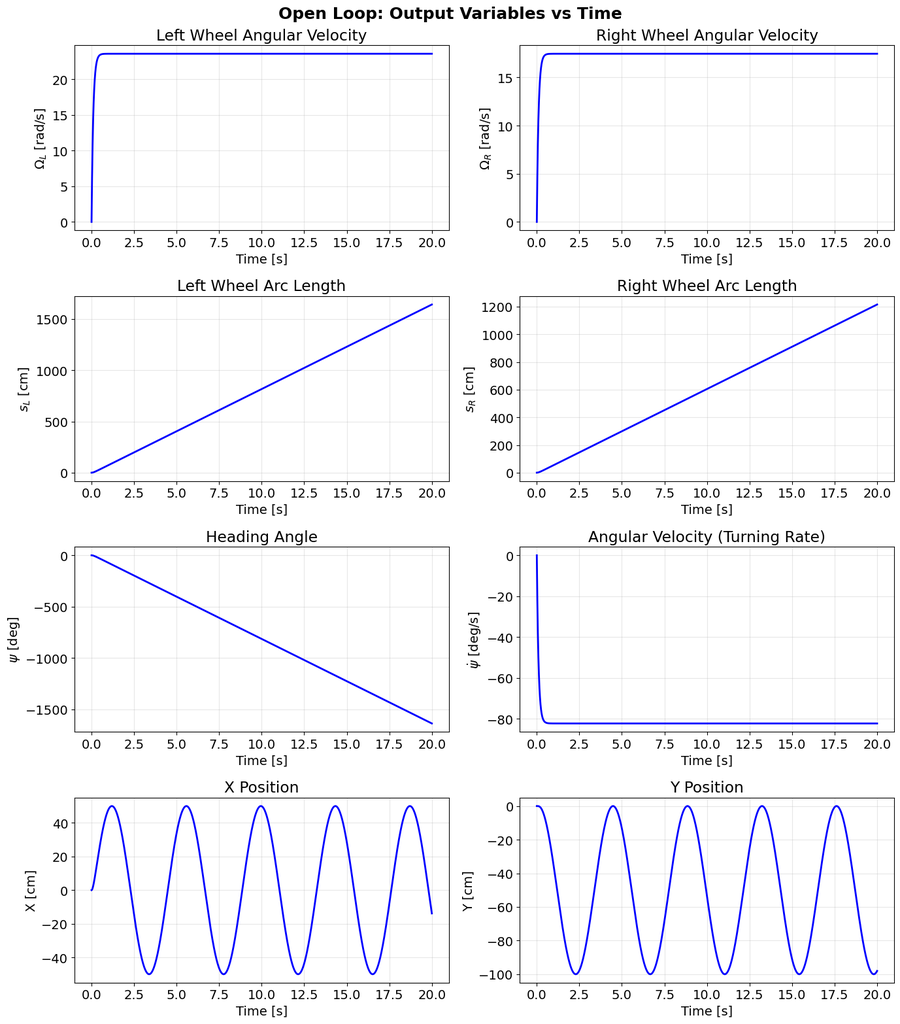

```python
# Set font size for better readability
rc('font', **{'size': 14})

# Plot formatting done by claude.ai
# Create a figure with 4 rows × 2 columns of subplots
fig, axes = pyplot.subplots(4, 2, figsize=(14, 16))
fig.suptitle('Open Loop: Output Variables vs Time', fontsize=18, fontweight='bold')

# Left wheel velocity
axes[0, 0].plot(t_OL, y_OL[:,0], 'b-', linewidth=2)
axes[0, 0].set_xlabel('Time [s]')
axes[0, 0].set_ylabel(r'$\Omega_L$ [rad/s]')
axes[0, 0].set_title('Left Wheel Angular Velocity')
axes[0, 0].grid(True, alpha=0.3)

# Right wheel velocity
axes[0, 1].plot(t_OL, y_OL[:,1], 'b-', linewidth=2)
axes[0, 1].set_xlabel('Time [s]')
axes[0, 1].set_ylabel(r'$\Omega_R$ [rad/s]')
axes[0, 1].set_title('Right Wheel Angular Velocity')
axes[0, 1].grid(True, alpha=0.3)

# Left wheel arc length
axes[1, 0].plot(t_OL, y_OL[:,2], 'b-', linewidth=2)
axes[1, 0].set_xlabel('Time [s]')
axes[1, 0].set_ylabel(r'$s_L$ [cm]')
axes[1, 0].set_title('Left Wheel Arc Length')
axes[1, 0].grid(True, alpha=0.3)

# Right wheel arc length
axes[1, 1].plot(t_OL, y_OL[:,3], 'b-', linewidth=2)
axes[1, 1].set_xlabel('Time [s]')
axes[1, 1].set_ylabel(r'$s_R$ [cm]')
axes[1, 1].set_title('Right Wheel Arc Length')
axes[1, 1].grid(True, alpha=0.3)

# Heading angle
axes[2, 0].plot(t_OL, y_OL[:,4]*180/pi, 'b-', linewidth=2)
axes[2, 0].set_xlabel('Time [s]')
axes[2, 0].set_ylabel(r'$\psi$ [deg]')
axes[2, 0].set_title('Heading Angle')
axes[2, 0].grid(True, alpha=0.3)

# Angular velocity (turning rate)
axes[2, 1].plot(t_OL, y_OL[:,5]*180/pi, 'b-', linewidth=2)
axes[2, 1].set_xlabel('Time [s]')
axes[2, 1].set_ylabel(r'$\dot{\psi}$ [deg/s]')
axes[2, 1].set_title('Angular Velocity (Turning Rate)')
axes[2, 1].grid(True, alpha=0.3)

# X position
axes[3, 0].plot(t_OL, y_OL[:,6], 'b-', linewidth=2)
axes[3, 0].set_xlabel('Time [s]')
axes[3, 0].set_ylabel('X [cm]')
axes[3, 0].set_title('X Position')
axes[3, 0].grid(True, alpha=0.3)

# Y position
axes[3, 1].plot(t_OL, y_OL[:,7], 'b-', linewidth=2)
axes[3, 1].set_xlabel('Time [s]')
axes[3, 1].set_ylabel('Y [cm]')
axes[3, 1].set_title('Y Position')
axes[3, 1].grid(True, alpha=0.3)

pyplot.tight_layout()
pyplot.show()
```

## Plotting the Open-Loop Position on an X-Y Graph

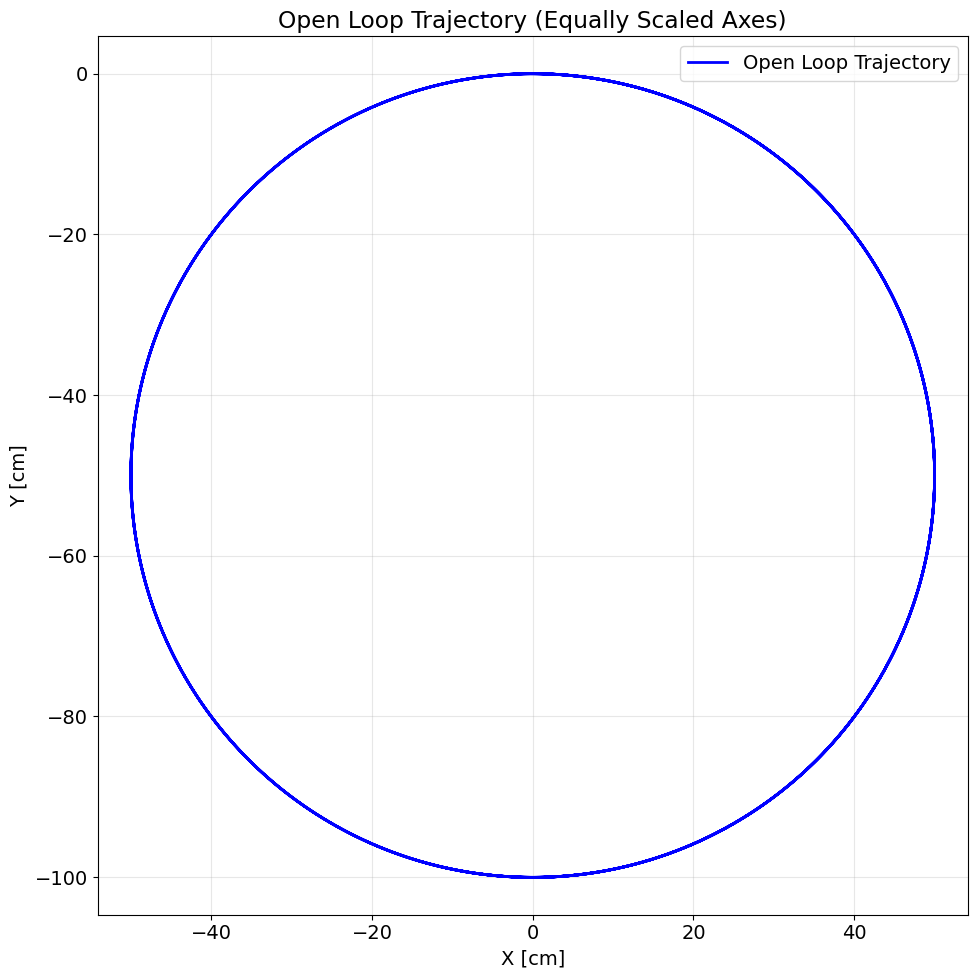

```python
# Set font size for better readability
rc('font', **{'size': 14})

pyplot.figure(figsize=(10, 10))

# Plot trajectory
pyplot.plot(y_OL[:,6], y_OL[:,7], 'b-', linewidth=2, label='Open Loop Trajectory')

pyplot.xlabel('X [cm]')
pyplot.ylabel('Y [cm]')
pyplot.title('Open Loop Trajectory (Equally Scaled Axes)')
pyplot.axis('equal') # scale axis
pyplot.grid(True, alpha=0.3)
pyplot.legend(loc='best')
pyplot.tight_layout()
pyplot.show()
```

# Running the Closed-Loop Simulation

```python
# Solve the closed loop system over a 20 second time window with 1 ms steps (1e-3)

t_CL, y_CL = RK4_solver(system_eqn_CL, x_0, [0, 20], 1e-3)  # 20 seconds
```

## Plotting the Closed-Loop Output Variables vs Time

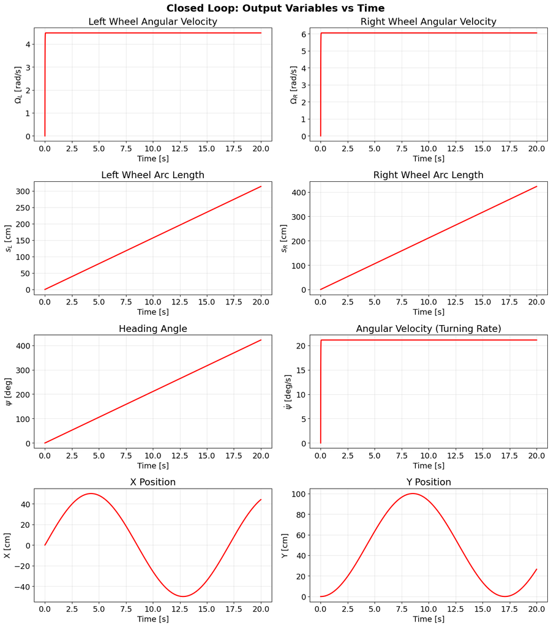

```python
# Set font size for better readability
rc('font', **{'size': 14})

# Create a figure with 4 rows × 2 columns of subplots
fig, axes = pyplot.subplots(4, 2, figsize=(14, 16))
fig.suptitle('Closed Loop: Output Variables vs Time', fontsize=18, fontweight='bold')

# Left wheel velocity
axes[0, 0].plot(t_CL, y_CL[:,0], 'r-', linewidth=2)
axes[0, 0].set_xlabel('Time [s]')
axes[0, 0].set_ylabel(r'$\Omega_L$ [rad/s]')
axes[0, 0].set_title('Left Wheel Angular Velocity')
axes[0, 0].grid(True, alpha=0.3)

# Right wheel velocity
axes[0, 1].plot(t_CL, y_CL[:,1], 'r-', linewidth=2)
axes[0, 1].set_xlabel('Time [s]')
axes[0, 1].set_ylabel(r'$\Omega_R$ [rad/s]')
axes[0, 1].set_title('Right Wheel Angular Velocity')
axes[0, 1].grid(True, alpha=0.3)

# Left wheel arc length
axes[1, 0].plot(t_CL, y_CL[:,2], 'r-', linewidth=2)
axes[1, 0].set_xlabel('Time [s]')
axes[1, 0].set_ylabel(r'$s_L$ [cm]')
axes[1, 0].set_title('Left Wheel Arc Length')
axes[1, 0].grid(True, alpha=0.3)

# Right wheel arc length
axes[1, 1].plot(t_CL, y_CL[:,3], 'r-', linewidth=2)
axes[1, 1].set_xlabel('Time [s]')
axes[1, 1].set_ylabel(r'$s_R$ [cm]')
axes[1, 1].set_title('Right Wheel Arc Length')
axes[1, 1].grid(True, alpha=0.3)

# Heading angle
axes[2, 0].plot(t_CL, y_CL[:,4]*180/pi, 'r-', linewidth=2)
axes[2, 0].set_xlabel('Time [s]')
axes[2, 0].set_ylabel(r'$\psi$ [deg]')
axes[2, 0].set_title('Heading Angle')
axes[2, 0].grid(True, alpha=0.3)

# Angular velocity (turning rate)
axes[2, 1].plot(t_CL, y_CL[:,5]*180/pi, 'r-', linewidth=2)
axes[2, 1].set_xlabel('Time [s]')
axes[2, 1].set_ylabel(r'$\dot{\psi}$ [deg/s]')
axes[2, 1].set_title('Angular Velocity (Turning Rate)')
axes[2, 1].grid(True, alpha=0.3)

# X position
axes[3, 0].plot(t_CL, y_CL[:,6], 'r-', linewidth=2)
axes[3, 0].set_xlabel('Time [s]')
axes[3, 0].set_ylabel('X [cm]')
axes[3, 0].set_title('X Position')
axes[3, 0].grid(True, alpha=0.3)

# Y position
axes[3, 1].plot(t_CL, y_CL[:,7], 'r-', linewidth=2)
axes[3, 1].set_xlabel('Time [s]')
axes[3, 1].set_ylabel('Y [cm]')
axes[3, 1].set_title('Y Position')
axes[3, 1].grid(True, alpha=0.3)

pyplot.tight_layout()
pyplot.show()
```

## Plotting the Closed-Loop Position on an X-Y Graph

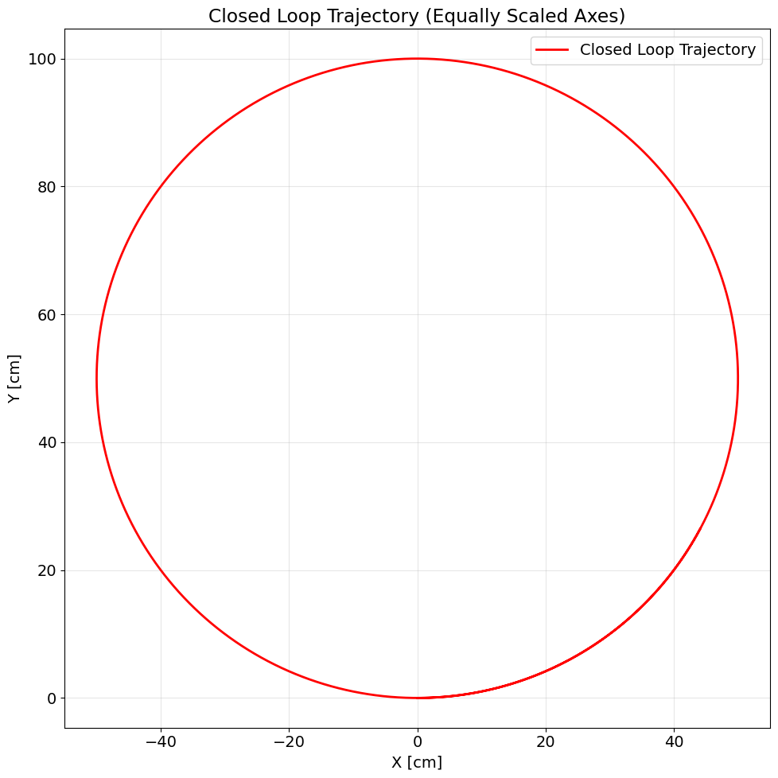

```python
# Set font size for better readability
rc('font', **{'size': 14})

pyplot.figure(figsize=(10, 10))

# Plot trajectory
pyplot.plot(y_CL[:,6], y_CL[:,7], 'r-', linewidth=2, label='Closed Loop Trajectory')

pyplot.xlabel('X [cm]')
pyplot.ylabel('Y [cm]')
pyplot.title('Closed Loop Trajectory (Equally Scaled Axes)')
pyplot.axis('equal')
pyplot.grid(True, alpha=0.3)
pyplot.legend(loc='best')
pyplot.tight_layout()
pyplot.show()
```

## Control Structure Block Diagram

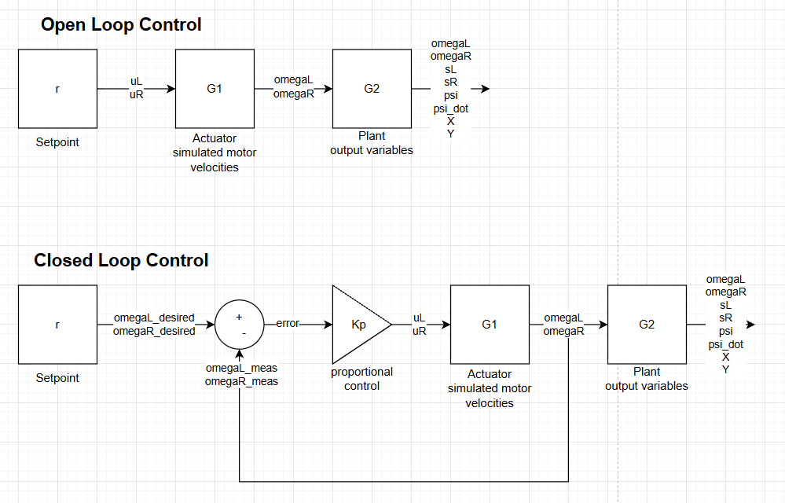

## Model Parameters

### Physical

Wheel Radius (r) = 3.5 cm  
Robot Width (w) = 14.9 cm  
Motor Gain (K) = 5.82 rad/V*s  
Motor Time constant (tau) = 0.1 s

### Control

Proportional Gain (Kp) = 2.0 V/rad/s  
Desired radius (R_desired) = 50 cm  
Desired velocity (v_desired) = 20 cm/s